# Approaches based on a discrete survival times specification

Karla Monterrubio-Gómez, Nathan Constantine-Cooke, and Catalina Vallejos

2022-11-15

# Dataset

In order to demonstrate the methods, we employ publicly available data.

The dataset used here corresponds to the Hodgkin’s disease (HD) study described in Pintilie, 2006. The dataset comprises 865 patients diagnosed with early stage (I or II) HD, and which were treated either with radiation (RT) or with radiation and chemotherapy (CMT).

The recorded data includes:

- age: Age (years)
- sex: Sex, F=female and M=Male.
- trtgiven: Treatment given, RT=Radiation, CMT=Chemotherapy and radiation
- medwidsi: Size of mediastinum involvement, N=No, S=Small, L=Large
- extranod: Extranodal disease, Y=Extranodal disease, N= Nodal disease
- clinstg: Clinical stage, 1=Stage I, 2=Stage II
- time: time to failure (years) calculated from the date of diagnosis
- status: 0=censoring, 1=relapse and 2=death.

We now load and display the structure of the HD dataset:

```r
library(readr)
hd <- data.frame(read_csv("../Data/HD/hd.csv",
                          col_types = cols(X1 = col_skip())))
str(hd)
```

```
#> 'data.frame':    865 obs. of  9 variables:
#>  $ ...1    : num  1 2 3 4 5 6 7 8 9 10 ...
#>  $ age     : num  64 63 17 63 21 37 41 35 27 32 ...
#>  $ sex     : chr  "F" "M" "M" "M" ...
#>  $ trtgiven: chr  "RT" "RT" "RT" "RT" ...
#>  $ medwidsi: chr  "N" "N" "N" "N" ...
#>  $ extranod: chr  "N" "N" "N" "N" ...
#>  $ clinstg : num  1 1 2 2 2 1 2 2 2 2 ...
#>  $ time    : num  3.1 15.9 0.9 13.1 35.9 1.1 2.5 0.003 4.1 28.1 ...
#>  $ status  : num  2 2 1 2 0 1 1 1 1 0 ...
```

To proceed with the analysis, it is important to change the data type of sex, trtgiven, medwidsi, and extranod from character to factor. Similarly, we convert clinstg from numeric to factor.

```r
hd$sex      <- as.factor(hd$sex)
hd$trtgiven <- as.factor(hd$trtgiven)
hd$medwidsi <- as.factor(hd$medwidsi)
hd$extranod <- as.factor(hd$extranod)
hd$clinstg  <- as.factor(hd$clinstg)
```

Now, we explore the number of events for each event type:

```r
require(pander)
pander::pander(table(hd$status))
```

| 0 | 1 | 2 |
| --- | --- | --- |
| 439 | 291 | 135 |

Thus, we have 439 censored patients, 291 with relapse, and 135 who died. From now on, we assume that the event of interest is relapse, i.e. status=1.

In order to create a test set, we use stratified sampling to partition our dataset into 80% for train and 20% for test.

```r
library(splitstackshape)
set.seed(2022)
split_data <- stratified(hd, c("status"), 0.8, bothSets = TRUE)
hd_train   <- split_data$SAMP1
hd_test    <- split_data$SAMP2
```

Now, we explore the number of observations per status in both train and test set:

```r
pander::pander(table(hd_train$status))
```

| 0 | 1 | 2 |
| --- | --- | --- |
| 351 | 233 | 108 |

```r
pander::pander(table(hd_test$status))
```

| 0 | 1 | 2 |
| --- | --- | --- |
| 88 | 58 | 27 |

# BART

BART has a well documented vignette (Sparapani, Spanbauer, and McCulloch (2021)). Here, we focus only on demonstrating its usage for a CR setting, which corresponds to Section 5.3 in Sparapani, Spanbauer, and McCulloch (2021). In the following, we fit the model with the two different likelihood formulations to compare the obtained estimates.

The first step is to recast the data creating dummy variables for all categorical covariates. This is done for both train and test sets:

```r
library(nnet)
library(survival)
library(BART)
library(stats)

xtrain = model.matrix(~. , hd_train[,c(1:6)])[,-1]
xtest = model.matrix(~. , hd_test[,c(1:6)])[,-1]
```

## Model formulation 1

The first method employs two binary likelihoods. The first one is a BART survival model for the time to the first event and the second model accounts for the probability of the event being of type $k=1$ given that the it occurred. The user can fit the model by using function `crisk2.bart()`. Note that the required binary event indicators $y_{ijk}$ can be constructed beforehand with `surv.pre.bart()` and passed to the function using the `y.train` argument. Instead, here we pass arguments `times` and `delta` which will construct event indicators internally. If we are interested in predictions, the test set can be passed directly when fitting the model through the argument `x.test`. Arguments to control the MCMC sampler are: `ndpost`, `nskip`, and `keepevery`. Their functionality is documented in the help file for the `crisk2.bart()` function.

```r
bart1 <- crisk2.bart(x.train = xtrain,
                     times = hd_train$time,   # needed if ytrain is not provided
                     delta = hd_train$status, # needed if ytrain is not provided
                     x.test = xtest,
                     sparse = FALSE,          # set equal TRUE for variable selection
                     type = 'pbart',
                     ntree = 30, numcut = 100,
                     ndpost = 500, nskip = 100, keepevery = 10L,
                     seed = 99)
```

Note that the code shown above does not use multi-threading, but BART permits its usage by using `mc.crisk2.bart()` function instead of `crisk2.bart()`.

Studying convergence diagnosis of the MCMC chains is key to ensure the predictions are valid. In order to do that one needs to fit the model using the train set as test set, by setting the argument `x.test = xtrain`. Then we can use Geweke diagnostics to assess converge

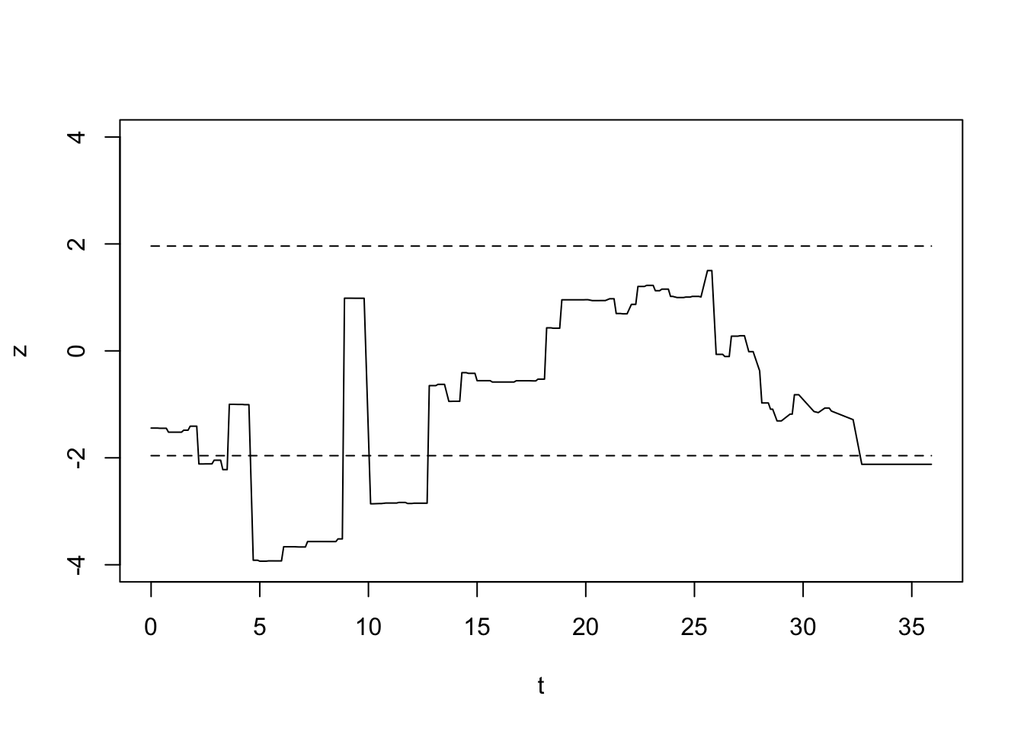

```r
bart1.chains <- crisk2.bart(x.train = xtrain,
                     times = hd_train$time,   # needed if ytrain is not provided
                     delta = hd_train$status, # needed if ytrain is not provided
                     x.test = xtrain,
                     sparse = FALSE,          # set equal TRUE for variable selection
                     type = 'pbart',
                     ntree = 30, numcut = 100,
                     ndpost = 500, nskip = 100, keepevery = 10L,
                     seed = 99)

h <- bart1.chains$K
samples <- bart1.chains$yhat.test[, 1:h]
z <- gewekediag(samples)$z
lim <- max(c(4, abs(z)))

# z scores vs. time for patient 1
plot(bart1.chains$times, z, ylim=c(-lim, lim), type='l',xlab='t', ylab='z')
lines(bart1.chains$times, rep(1.96, h), type='l', lty=2)
lines(bart1.chains$times, rep(-1.96, h), type='l', lty=2)
```

Notice that the Geweke statistics exceed the $95\%$ limits several times, suggesting the chains have not converged. Thus, the MCMC should be run for longer thining to obtain valid estimates.

CIFs for the subjects in the test set can be obtained through `cif.test.mean()`. This provides the posterior mean across MCMC samples. In addition, credible intervals can be computed from the samples saved in `cif.test`. First, we re-organised the predicted CIF for cause 1 for the test dataset. The constructed matrix contains one row per subject and the columns correspond to the unique time points at which it is evaluated. Second, we compute $95\%$ credible intervals.

```r
cif.pred <- matrix(bart1$cif.test.mean, nrow=nrow(xtest), byrow = TRUE )

# Compute 95% credible intervals and put in matrix format:
cif.025 <- apply(bart1$cif.test, 2, quantile, probs = 0.025)
cif.025 <- matrix(cif.025, nrow=nrow(xtest), byrow = TRUE)
cif.975 <- apply(bart1$cif.test, 2, quantile, probs = 0.975)
cif.975 <- matrix(cif.975, nrow=nrow(xtest), byrow = TRUE)
```

We show CIF curves for the first (red) and second (blue) individuals in the test set along with its corresponding credible intervals:

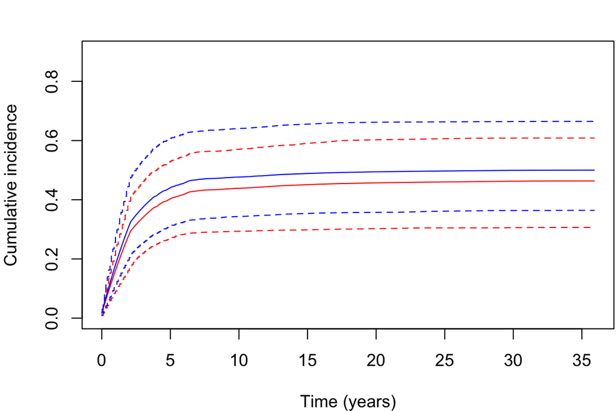

```r
par(mar = c(4, 4, 2, 0.1))

plot(bart1$times,
     cif.pred[1,],
     type = "l",
     col = "red",
     ylim = c(0, 0.9),
     xlab = "Time (years)",
     ylab = "Cumulative incidence")
points(bart1$times,cif.025[1,], col = "red", type ='s', lwd = 1, lty = 2)
points(bart1$times,cif.975[1,], col = "red", type = 's', lwd = 1, lty = 2)
lines(bart1$times,  cif.pred[2,], col="blue")
points(bart1$times,cif.025[2,], col = "blue", type ='s', lwd = 1, lty = 2)
points(bart1$times,cif.975[2,], col = "blue", type = 's', lwd = 1, lty = 2)
```

Similar to other approaches, BART permits to do predictions of the CIF at a specific time point (e.g. $t=5$ years) for a new dataset (e.g. `hd_test`). Note that predictions are only provided for time-points present in the training dataset. Below, we show results for the first 5 subjects in the test set.

```r
BART.pred <- matrix(bart1$cif.test.mean, nrow=nrow(xtest), byrow = TRUE )
BART.pred[1:5,which(bart1$times == 5)]
```

```
#> [1] 0.4032514 0.4406258 0.3618237 0.3324426 0.3320080
```

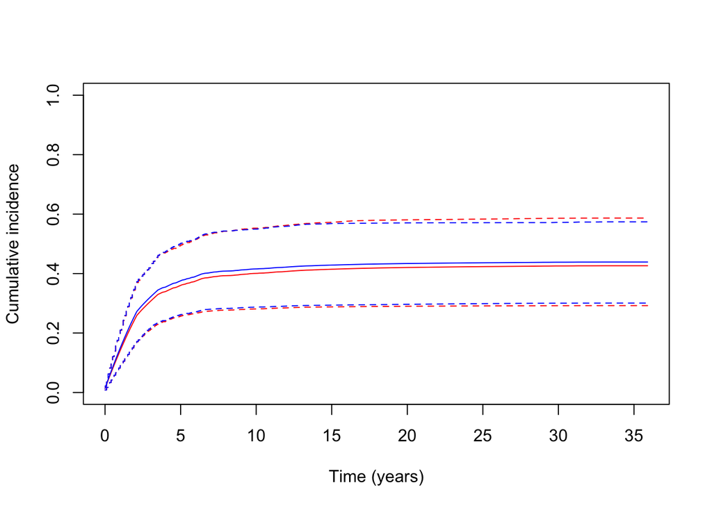

```r
pre <- surv.pre.bart(x.train=xtrain, x.test=xtest,
                     times=hd_train$time, delta=hd_train$status)

bart1.pred <- mc.crisk2.pwbart(pre$tx.test, pre$tx.test,
                         bart1.chains$treedraws, bart1.chains$treedraws2)

pre <- surv.pre.bart(x.train=xtrain, x.test=xtest, times=hd_train$time,
                     delta =hd_train$status)

bart1.pred <- predict(bart1.chains, newdata=pre$tx.test, newdata2=pre$tx.test)

cif.pred <- matrix(bart1.pred$cif.test.mean, nrow=nrow(xtest), byrow = TRUE )
cif.025 <- apply(bart1.pred$cif.test, 2, quantile, probs = 0.025)
cif.025 <- matrix(cif.025, nrow=nrow(xtest), byrow = TRUE)
cif.975 <- apply(bart1.pred$cif.test, 2, quantile, probs = 0.975)
cif.975 <- matrix(cif.975, nrow=nrow(xtest), byrow = TRUE)

plot(bart1.chains$times,
     cif.pred[1,],
     type = "l",
     col = "red",
     ylim = c(0, 1),
     xlab = "Time (years)",
     ylab = "Cumulative incidence")
points(bart1.chains$times,cif.025[1,], col = "red", type ='s', lwd = 1, lty = 2)
points(bart1.chains$times,cif.975[1,], col = "red", type = 's', lwd = 1, lty = 2)
lines(bart1.chains$times,  cif.pred[2,], col="blue")
points(bart1.chains$times,cif.025[2,], col = "blue", type ='s', lwd = 1, lty = 2)
points(bart1.chains$times,cif.975[2,], col = "blue", type = 's', lwd = 1, lty = 2)
```

### DART

It is possible to employ a sparse Dirichlet prior for variable selection (DART model). This will help us to determine variable importance. In order to fit such model we use again `crisk2.bart()` function and set the `sparse` argument equal to `TRUE`.

```r
dart1 <- crisk2.bart(x.train = xtrain,
                     times = hd_train$time,   # needed if ytrain is not provided
                     delta = hd_train$status, # needed if ytrain is not provided
                     x.test = xtest,
                     sparse = TRUE,          # set equal TRUE for variable selection
                     type = 'pbart',
                     ntree = 30, numcut = 100,
                     ndpost = 500, nskip = 200, keepevery = 10L,
                     seed = 99)
```

The output of the function is the same as discussed in the previous section. Therefore, the CIFs can be estimated as shown before.

A plot that illustrates which variables to select is shown:

```r
P = ncol(xtrain)    # use to set thereshold probability for each covariate

dart1$varprob.mean > 1/P
```

```
#>          t       ...1        age       sexM trtgivenRT  medwidsiN  medwidsiS
#>       TRUE       TRUE      FALSE      FALSE      FALSE      FALSE       TRUE
#>  extranodY
#>      FALSE
```

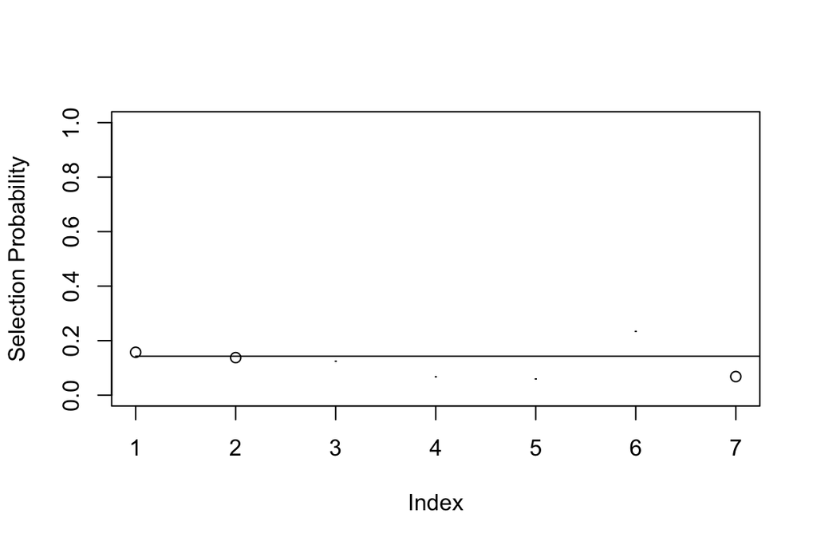

```r
plot(dart1$varprob.mean[-1],
     ylab='Selection Probability',
     ylim=c(0, 1),
     pch = 1+45*(dart1$varprob.mean <= 1/P))
lines(c(1, P+1), c(1/P, 1/P))
```

## Model formulation 2

This approach is discussed in Section 3.2 of Sparapani et al. (2020) and fits also two separate BART probit models. The first model, corresponds to the conditional probability of a cause $k=1$ event at a given time. The second, models the conditional probability of an event of type $k=2$ at a specific time, given that the individual is still at risk and did not experience a type $k=1$ event. In this case, the model is fit with function `crisk.bart()`:

```r
bart2 <- crisk.bart(x.train = xtrain, times = hd_train$time,
                    delta=hd_train$status,
                    x.test = xtest,
                    sparse=FALSE,
                    type='pbart',
                    ntree = 30, numcut = 100,
                    ndpost = 500, nskip = 100, keepevery = 10L,
                    seed=99)
# Parallel computation of the model is available using mc.crisk.bart
```

The output is the same as in model formulation 1.

```r
cif2.pred <- matrix(bart2$cif.test.mean, nrow=nrow(xtest), byrow = TRUE )

# Compute 95% credible intervals and put in matrix format:
cif2.025 <- apply(bart2$cif.test, 2, quantile, probs = 0.025)
cif2.025 <- matrix(cif2.025, nrow=nrow(xtest), byrow = TRUE)
cif2.975 <- apply(bart2$cif.test, 2, quantile, probs = 0.975)
cif2.975 <- matrix(cif2.975, nrow=nrow(xtest), byrow = TRUE)
```

We show CIF curves for patient 1 (red) and 2 (blue) in the test set along with its corresponding credible intervals:

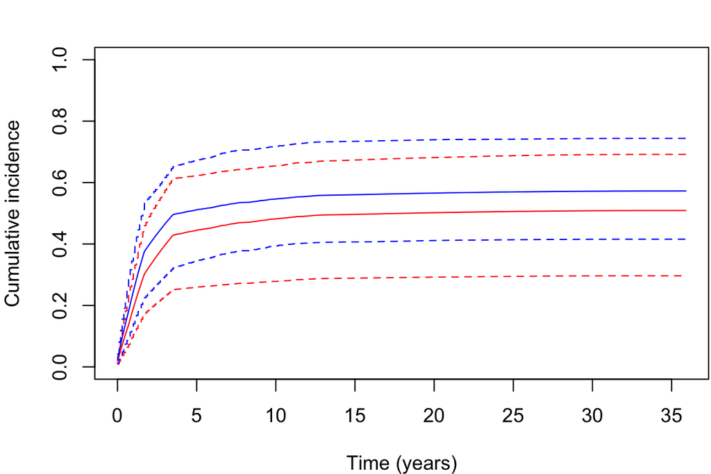

```r
par(mar = c(4, 4, 2, 0.1))

plot(bart2$times,
     cif2.pred[1,],
     type = "l",
     col = "red",
     ylim = c(0, 1),
     xlab = "Time (years)",
     ylab = "Cumulative incidence")
points(bart2$times,cif2.025[1,], col = "red", type ='s', lwd = 1, lty = 2)
points(bart2$times,cif2.975[1,], col = "red", type = 's', lwd = 1, lty = 2)
lines(bart2$times,  cif2.pred[2,], col="blue")
points(bart2$times,cif2.025[2,], col = "blue", type ='s', lwd = 1, lty = 2)
points(bart2$times,cif2.975[2,], col = "blue", type = 's', lwd = 1, lty = 2)
```

```r
surv2.pred <- matrix(bart2$surv.test.mean, nrow=nrow(xtest), byrow = TRUE )
surv2.pred[1:5,which(bart2$times == 30.5)]
```

```
#> [1] 0.2687430 0.2329984 0.4069612 0.4165222 0.4143782
```

```r
# Compute 95% credible intervals and put in matrix format:
surv2.025 <- apply(bart2$surv.test, 2, quantile, probs = 0.025)
surv2.025 <- matrix(surv2.025, nrow=nrow(xtest), byrow = TRUE)
surv2.975 <- apply(bart2$surv.test, 2, quantile, probs = 0.975)
surv2.975 <- matrix(surv2.975, nrow=nrow(xtest), byrow = TRUE)
```

A plot for the first subject is shown below:

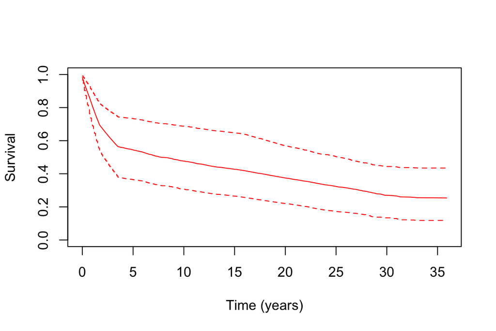

```r
plot(bart2$times,
     surv2.pred[1,],
     type = "l",
     col = "red",
     ylim = c(0, 1),
     xlab = "Time (years)",
     ylab = "Survival")
points(bart2$times,surv2.025[1,], col = "red", type ='s', lwd = 1, lty = 2)
points(bart2$times,surv2.975[1,], col = "red", type = 's', lwd = 1, lty = 2)
```

[figure not shown]

```r
plot(bart1$times,bart1$cif.pred[1,],lwd=2,type="l", col=2, ylim=c(0,1),
     main="Comparison of different formulations for test patient 1",
     xlab="Time", ylab="CIF(t)")
lines(bart2$cif2.pred[2,], col=3,lwd=3)
      legend("topright",
       legend=c("Formulation 1", "Formulation 2"),
       col=c("#009999", "#FFCC00"), lty=c(1,1))
```

# References

Sparapani, Rodney, Brent R Logan, Robert E McCulloch, and Purushottam W Laud. 2020. “Nonparametric Competing Risks Analysis Using Bayesian Additive Regression Trees.” *Statistical Methods in Medical Research* 29 (1): 57–77. https://doi.org/10.1177/0962280218822140.

Sparapani, Rodney, Charles Spanbauer, and Robert McCulloch. 2021. “Nonparametric Machine Learning and Efficient Computation with Bayesian Additive Regression Trees: The BART r Package.” *Journal of Statistical Software* 97: 1–66.